# Describing MentPy's use of Lie Algebra generation

```python
# Essential imports
from __future__ import annotations

import numpy as np
import networkx as nx

from graphix import Circuit, Statevec, Pattern, command
from graphix.opengraph import OpenGraph
from graphix.pauli import Pauli
from graphix.ops import Ops
from graphix.states import BasicStates
import graphix.instruction as instruction
from graphix.fundamentals import Plane
import graphix_mentpy_interface as gmi

import mentpy as mp
```

### Example "circuit" in MentPy

```
(<Figure size 800x300 with 1 Axes>, <Axes: >)
```

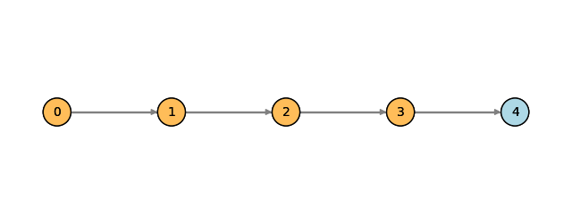

```python
gs = mp.GraphState()
gs.add_edges_from([(0, 1), (1, 2), (2, 3), (3, 4)])
mbcirc = mp.MBQCircuit(gs, input_nodes=[0], output_nodes=[4])
mp.draw(mbcirc)
```

This graph state doesn't have defined measurements, and so MentPy considers all non-output nodes $O^c$ to be trainable for QML.

```python
mbcirc.trainable_nodes
```

```
[0, 1, 2, 3]
```

Fixing a node takes it out of the trainable set.

```python
mbcirc[2] = mp.Ment(0.5, "YZ")
mbcirc.trainable_nodes
```

```
[0, 1, 3]
```

```python
circuit_1 = Circuit(1, instr=[instruction.H(0)])
pattern_1 = circuit_1.transpile().pattern
pattern_in_mentpy = gmi.graphix_pattern_to_mentpy(pattern_1)
print("Trainable nodes: ", pattern_in_mentpy.trainable_nodes)
```

```
Trainable nodes:  [0]
```

MentPy was created to study QML. The trainable nodes can be studied using the utils.calculate_lie_algebra() function to determine the set of gates that could be implemented (depending on the angles chosen).

```python
# Returning to the original graph state with 3 remaining trainable nodes
ops = mp.utils.calculate_lie_algebra(mbcirc)
print(ops)
```

```
Z
X
Y
I
```

This says that this circuit allows you to find angles such that all rotations can be generated, which we know from the Measurement Calculus. This changes if some of the trainable nodes are fixed.

```python
mbcirc[0] = mp.Ment(0.5, "YZ")
mbcirc[1] = mp.Ment(0.5, "YZ")
print("Trainable nodes: ", mbcirc.trainable_nodes)
```

```
Trainable nodes:  [3]
```

```python
ops = mp.utils.calculate_lie_algebra(mbcirc)
print(ops)
```

```
X
I
```

According to the paper (Calderon et al. 2025), the Lie algebra is useful to know as a measure of how many gates can be implemented by a circuit with parameterised measurements. It also has some relation to the presence of barren plateaus in QML.

Other more relevant use cases include more efficient simulation of certain circuits and improved ansatz/optimisation in QAOA (see Goh et al. 2025). We can probably test these things mostly with existing functionality in Graphix, making use of Lie algebra calculation in MentPy.

```
Flow detected in the graph.
```

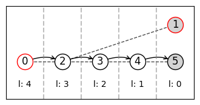

```
Trainable nodes:  [0, 2, 4]
[[Pauli.Z, Pauli.Z], [Pauli.X, Pauli.I], [Pauli.Y, Pauli.Z], [Pauli.I, Pauli.I]]
```

```python
circuit_2 = Circuit(2, instr=[instruction.CNOT(0,1), instruction.Z(0)])
pattern_2 = circuit_2.transpile().pattern
pattern_2.draw_graph(False)
pattern_in_mentpy_2 = gmi.graphix_pattern_to_mentpy(pattern_2)
print("Trainable nodes: ", pattern_in_mentpy_2.trainable_nodes)
# Calculate Lie algebra directly from the pattern
lie_algebra = gmi.calculate_lie_algebra(pattern_2)
print(lie_algebra)
```

Here, the Lie algebra is represented as a set of basis elements, where for example `[Pauli.Z, Pauli.Z]` means $Z_1 \otimes Z_2$.